# Efecto Airbnb en Madrid

Este informe se ha generado automáticamente con R a partir del [script de Rmarkdown](https://github.com/montera34/airbnbeuskadi/tree/master/analisis/montera34/airbnb-informe-ciudad.Rmd) disponible en el [repositorio airbnbeuskadi](https://github.com/montera34/airbnbeuskadi/).

## Datos

- InsideAirbnb.com/Madrid y Datahippo.org
- Fecha scraping: 2018-01-17 y 2018-04-16 respectivamente

## Resumen

En **Madrid** hay publicados 21570 anuncios de Airbnb, que tienen capacidad para 69832 personas (accommodates).

De esos anuncios 0 han sido dados de alta (lo que supone un 0.0 % del municipio).

Estos anuncios (listings, en la terminología de Airbnb) han sido publicados por 12448 anfitriones.

## Anfitriones en Airbnb

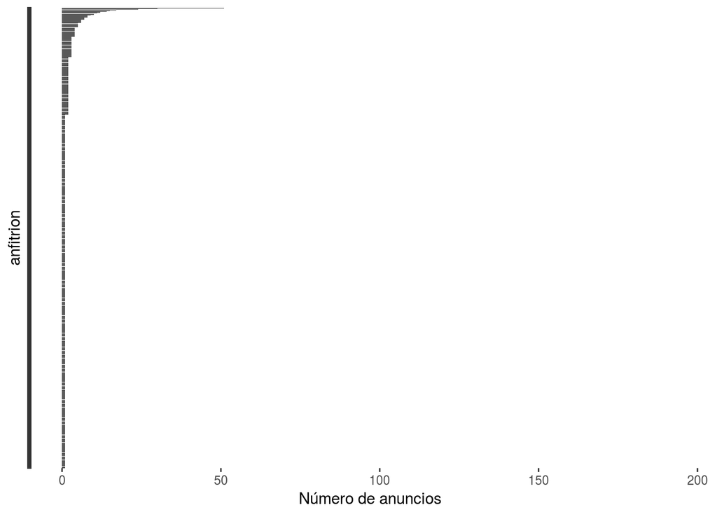

### Los anfitriones con más alojamientos

Los 20 anfitriones con más alojamientos (id)

| host_id | alojamientos |
| --- | --- |
| 102947901 | 194 |
| 3566146 | 122 |
| 54310958 | 119 |
| 143666717 | 109 |
| 117750911 | 96 |
| 27526991 | 76 |
| 99018982 | 71 |
| 100336740 | 69 |
| 28038703 | 64 |
| 1408525 | 63 |
| 117751530 | 60 |
| 5542111 | 53 |
| 159558182 | 51 |
| 142388035 | 47 |
| 37291567 | 45 |
| 138720343 | 44 |
| 85138877 | 42 |
| 12030420 | 41 |
| 60047857 | 40 |
| 23441165 | 39 |

### Los anfitriones con más plazas

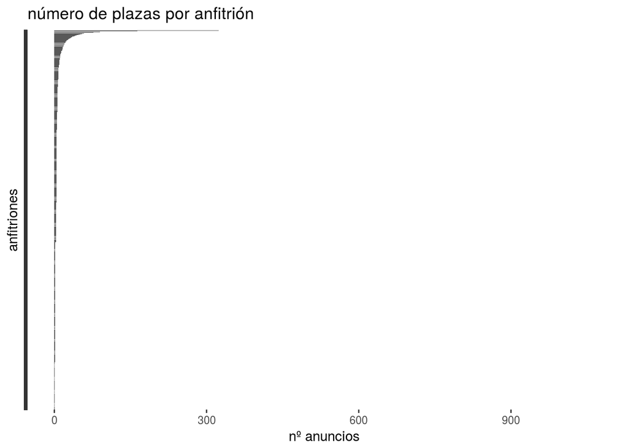

Los 10 primeros anfitriones (0.1% del total de anfitriones) con más plazas tienen 4106 plazas disponibles (que son el 5.9% del total de plazas).

Los 20 primeros anfitriones (0.2% del total de anfitriones) con más plazas tienen 6051 plazas disponibles (que son el 8.7% del total de plazas).

Los 50 primeros anfitriones (0.4% del total de anfitriones) con más plazas tienen 9540 plazas disponibles (que son el 13.7% del total de plazas).

Los 100 primeros anfitriones (0.8% del total de anfitriones) con más plazas tienen 13167 plazas disponibles (que son el 18.9% del total de plazas).

| host_id | plazas |
| --- | --- |
| 102947901 | 1064 |
| 3566146 | 540 |
| 54310958 | 525 |
| 27526991 | 361 |
| 99018982 | 357 |
| 100336740 | 324 |
| 28038703 | 242 |
| 159558182 | 241 |
| 1408525 | 226 |
| 96147078 | 226 |
| 138720343 | 222 |
| 12030420 | 209 |
| 5542111 | 207 |
| 60047857 | 204 |
| 37291567 | 202 |
| 85138877 | 194 |
| 143666717 | 185 |
| 22127357 | 182 |
| 14472608 | 170 |
| 156279074 | 170 |
| 51564174 | 164 |
| 32046323 | 159 |
| 40877988 | 154 |
| 142388035 | 148 |
| 4190343 | 134 |
| 157114944 | 132 |
| 28786243 | 129 |
| 2516266 | 128 |
| 50262565 | 128 |
| 1718458 | 124 |